# **secr** simulations MhS

Murray Efford

2026-04-03

# Effect of individual heterogeneity in detection parameter $\lambda_0$ on spatial trend estimates MhS

The simulations described here are part of a series documenting the effect of breaching assumptions of spatially explicit capture–recapture models.

Variation among individuals in the probability of detection is a known cause of bias in many domains of capture–recapture. However, trend estimates are fairly robust (see Hines and Nichols 2002 for non-spatial scenarios, but “These approximations indicate that trap response is an especially important assumption violation that can produce substantial bias”.)

MhS was extended 2026-04-02 to include a fit with individual covariates. These results are saved in a separate object MhSsims2.

## Settings

Square grid of 100 binary proximity detectors at spacing $c = 2\sigma$.

The same conditions used for simulation and fitting.

| Parameter | Value(s) |
| --- | --- |
| detectfn | ‘HHN’ |
| D | approx $1 \sigma^{-2}$ |
| mean lambda0 | 0.2 |
| mean sigma | c/2 |
| noccasions | 5 |
| buffer | $4\sigma$ |
| nx | 64 |

## Package version, date and platform

```r
source('../setup.R')
library(fields)  # for Gaussian random field
runsim  <- FALSE
runsim2 <- FALSE
runsim3 <- TRUE
results <- TRUE
figures <- TRUE
cache   <- FALSE
nrepl   <- 2000
nrepl2  <- 500
nrepl3  <- 50
metadata(runsim) # if FALSE picks up saved metadata.RDS
```

```
## R version 4.5.1 (2025-06-13 ucrt)
## Platform   x86_64-w64-mingw32/x64
## Running    Windows 11 x64 (build 26200)
## secr       5.4.3 2026-03-25
## secrdesign 2.10.1 2026-03-25
## Threads    20
## nrepl      20
## Run        Wed Apr  1 23:39:16 2026
```

Number of threads is set in setup.R.

Note: ‘grdevice’ is set in setup.R to ‘ragg_png’ allowing graphics on NeSI.

Density model changed 2025-09-08 to log D = beta0 + beta1 * grf, where grf is Gaussian random field generated by function fields::circulantEmbedding and scaled 0–1.

## Simulation code

### Define MhS scenarios

This function draws unique levels of the detection parameter lambda0 from a log-normal distribution for each member of a simulated population when used as the ‘covariates’ argument of `sim.popn`.

```r
popn.covariates <- function (animals, ...) {
    arg <- list(...)
    CVl <- if (is.null(arg$CVlambda0)) 0 else arg$CVlambda0
    mnl <- arg$lambda0
    mns <- arg$sigma
    n <- nrow(animals)
    data.frame(lambda0 = secr::rlnormCV(n, mnl, CVl), sigma = rep(mns,n))
}
```

The population arguments passed to run.scenarios include the mean and CV of each detection parameter.

```r
oneD <- function (mask, parm = list(beta0 = 8, beta1 = 1, aRange = 5), savegrf = TRUE) {
    grid <- list(x = unique(mask$x), y = unique(mask$y))
    obj  <- fields::circulantEmbeddingSetup(
        grid, Covariance = "Exponential", aRange = parm$aRange)
    grf  <- fields::circulantEmbedding( obj)
    grf  <- pnorm(as.numeric(grf))  # transform to (0,1)
    out  <- exp(parm$beta0 + parm$beta1*grf)
    if (savegrf) attr(out, 'grf') <- grf
    out
}
poparg <- expand.arg(
        model2D    = 'IHP',
        Ndist      = 'poisson',
        covariates = "popn.covariates",
        keep.mask  = TRUE,
        lambda0    = 0.2,
        sigma      = 1,
        CVlambda0  = seq(0,0.8,0.2)
)
beta0 <- log(2000)
beta1 <- log(10)
for (i in 1:5) {
    poparg[[i]]$D <- oneD
    poparg[[i]]$details <- list(beta0 = beta0, beta1 = beta1, aRange = 5)
}

scen <- make.scenarios(
    D          = 10000,   # approximate! overridden by grf
    noccasions = 5,
    detectfn   = 14,
    lambda0    = 0.2,
    sigma      = 1,        # m
    popindex   = 1:length(poparg),
    fitindex   = 1)
```

```r
# warning: this summary relates to a constant density of 10000
# different counts result from the modelled grf density
grid <- make.grid(nx = 10, ny = 10, spacing = 2, detector = "proximity")
scenarioSummary(scen, grid)
```

```
##   scenario trapsindex noccasions nrepeats     D lambda0 sigma detectfn     En     Er     Em    En2
## 1        1          1          5        1 10000     0.2     1       14 338.51 259.73 168.61 130.99
## 2        2          1          5        1 10000     0.2     1       14 338.51 259.73 168.61 130.99
## 3        3          1          5        1 10000     0.2     1       14 338.51 259.73 168.61 130.99
## 4        4          1          5        1 10000     0.2     1       14 338.51 259.73 168.61 130.99
## 5        5          1          5        1 10000     0.2     1       14 338.51 259.73 168.61 130.99
##        esa CF rotRSE rotRSEB arrayN arrayspace arrayspan saturation detperHR.median k
## 1 0.033851  1  0.062  0.0484    100          2    25.456    0.71539               4 1
## 2 0.033851  1  0.062  0.0484    100          2    25.456    0.71539               4 1
## 3 0.033851  1  0.062  0.0484    100          2    25.456    0.71539               4 1
## 4 0.033851  1  0.062  0.0484    100          2    25.456    0.71539               4 1
## 5 0.033851  1  0.062  0.0484    100          2    25.456    0.71539               4 1
```

### Example

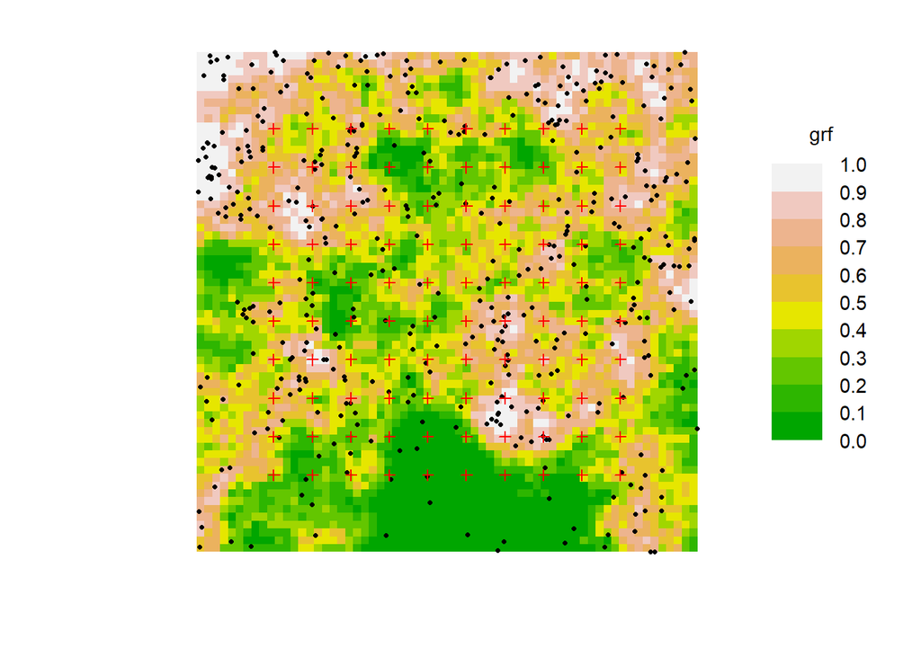

Fig. 1. Realisation of LGCP intensity surface and simulated AC locations.

```r
set.seed(1234)
msk <- make.mask(grid, buffer=4)
D <- oneD(msk, parm = list(beta0 = beta0, beta1 = beta1, aRange = 5), savegrf = TRUE)
covariates(msk)$grf <-  attr(D, 'grf')
covariates(msk)$D <-  D
pop <- sim.popn(D = D, core = msk, buffer = 0, model2D = "IHP")
ch <- sim.capthist(grid, popn = pop, detectpar = list(lambda0 = 0.1, sigma = 1),
                   noccasions = 5, detectfn = 14, savepopn = TRUE)
par(mar = c(3,1,1,2))
plot(msk, cov = 'grf', dots = F, border = 1)
plot(pop, cex = 0.5, pch = 16, frame = FALSE, add = TRUE)
plot(grid, add = TRUE)
```

### Run MhS simulations

Package ‘fields’ offers function circulantEmbedding() to generate a Gaussian random field.

```r
# clunky way to add grf as mask covariate
# run.scenarios adds covariates of mask saved from sim.popn() to fitarg$mask (secrdesign>2025-08-16)
CHfn <- function(traps, popn, detectfn, detectpar, noccasions) {
    ch <- sim.capthist(traps, popn, detectfn, detectpar = list(individual = TRUE),
                       noccasions, savepopn = TRUE, renumber = FALSE)
    covariates(ch)$lam <- covariates(popn)[rownames(ch),]$lambda0
    ch <- binCovariate(ch, 'lam', width = 0.05)
    tmp <- attr(attr(ch,'popn'),'mask')
    covariates(tmp)$grf <- attr(covariates(tmp)$D, 'grf')
    attr(attr(ch,'popn'),'mask') <- tmp
    ch
}
mycoef <- function(object, ...) {
  emptycoef <- function (rownames) {
    nr <- length(rownames)
    rNA <- rep(NA, nr)
    data.frame(beta = rNA, SE.beta = rNA, lcl = rNA, ucl = rNA, row.names = rownames)
  }
  if (inherits(object, 'secr')) {
      Dbar <- mean(covariates(object$mask)$D)
    if (object$CL) {
      Dhat <- mean(covariates(derivedDsurface(object))$D.0)
      cvn <- CV(apply(object$capthist,1,sum))
      time <- object$proctime
      out <- rbind(derivedDcoef(object)[c('D', 'D.grf', 'lambda0', 'sigma'), ],
                   cvn = cvn,  Dbar = Dbar, Dhat = Dhat, time = time)
      out[c('cvn','Dbar','Dhat'), 2:4] <- NA
    }
    else {
      Dhat <- mean(covariates(predictDsurface(object))$D.0)
      cvn <- CV(apply(object$capthist,1,sum))
      time <- object$proctime
      out <- rbind(coef(object)[c('D', 'D.grf', 'lambda0', 'sigma'), ],
                   cvn = cvn,  Dbar = Dbar, Dhat = Dhat, time = time)
      out[c('cvn','Dbar','Dhat'), 2:4] <- NA
    }
      out
  }
  else emptycoef(c('D', 'D.grf', 'lambda0', 'sigma', 'cvn', 'Dbar', 'Dhat','time'))
}
exfn <- function (fits, vcv = FALSE, ...) {
  # fits is secrlist
  lapply(fits, function(fit) mycoef(fit))
}
msk <- make.mask(grid, nx = 64, buffer = 4)
```

```r
MhSsimsC <- run.scenarios(
    nrepl     = nrepl,
    scenarios = scen,
    trapset   = grid,
    maskset   = msk,
    fit       = FALSE,
    pop.args  = poparg,
    CH.function = "CHfn",
    seed      = 123)
saveRDS(MhSsimsC, file = 'MhSsimsC.RDS')
```

```r
fitarg1   <- list(
  list (
    list(detectfn = 'HHN', CL = TRUE,  model = list(lambda0 ~ 1, D~grf)),
    list(detectfn = 'HHN', CL = FALSE, model = list(lambda0 ~ 1, D~grf)),
    list(detectfn = 'HHN', CL = FALSE, model = list(lambda0 ~ 1, D~grf),
         details = list(distribution = "binomial"))
  )
)
MhSsims <- run.scenarios(
    nrepl     = nrepl,
    scenarios = scen,
    trapset   = grid,
    maskset   = msk,
    fit       = "multifit",
    pop.args  = poparg,
    CH.function = "CHfn",
    fit.args  = fitarg1,
    seed      = 123,
    extractfn = exfn)

saveRDS(MhSsims, file = 'MhSsims.RDS')
```

MhSsims completed with 2000 replicates on 20 threads in 1125.9 minutes.

Run lambda0 model separately because fitting takes much longer and we will use fewer replicates.

```r
fitarg2   <- list(
  list (
    list(detectfn = 'HHN', CL = TRUE,  model = list(lambda0 ~ 1, D~grf)),
    list(detectfn = 'HHN', CL = TRUE,  model = list(lambda0 ~ lam0.05, D~grf))
  )
)
MhSsims2 <- run.scenarios(
    nrepl     = nrepl2,
    scenarios = scen,
    trapset   = grid,
    maskset   = msk,
    fit       = "multifit",
    pop.args  = poparg,
    CH.function = "CHfn",
    fit.args  = fitarg2,
    seed      = 123,
    extractfn = exfn)
saveRDS(MhSsims2, file = 'MhSsims2.RDS')
```

MhSsims2 completed with 500 replicates on 20 threads in 1343.7 minutes.

```r
fitarg3   <- list(
  list (
    list(detectfn = 'HHN', CL = TRUE,  model = list(lambda0 ~ lam0.05, D~grf),
         details = list(lambda0 = 'identity'))
  )
)
MhSsims3 <- run.scenarios(
    nrepl     = nrepl3,
    scenarios = scen,
    trapset   = grid,
    maskset   = msk,
    fit       = "multifit",
    pop.args  = poparg,
    CH.function = "CHfn",
    fit.args  = fitarg3,
    seed      = 123,
    extractfn = exfn)
saveRDS(MhSsims3, file = 'MhSsims3.RDS')
```

MhSsims3 completed with 50 replicates on 20 threads in 184.2 minutes.

## Results

```r
mn <- function(x) mean(x, na.rm=TRUE)
se <- function(x) sd(x, na.rm=TRUE)/sqrt(sum(!is.na(x)))
nv <- function(x) sum(!is.na(x))
```

Counts

```r
MhSsimsC <- readRDS(file = 'MhSsimsC.RDS')
summary(MhSsimsC)
```

```
## run.scenarios(nrepl = nrepl, scenarios = scen, trapset = grid,
##     maskset = msk, pop.args = poparg, CH.function = "CHfn", fit = FALSE,
##     seed = 123)
##
## Replicates    2000
## Started       09:47:57 03 Apr 2026
## Run time      25.251  minutes
## Output class  selectedstatistics
##
## $constant
##             value
## trapsindex      1
## noccasions      5
## nrepeats        1
## D           10000
## lambda0       0.2
## sigma           1
## detectfn       14
## recapfactor     1
## detindex        1
## fitindex        1
## maskindex       1
##
## $varying
##  scenario popindex
##         1        1
##         2        2
##         3        3
##         4        4
##         5        5
##
## $detectors
##  trapsindex trapsname
##           1    traps1
##
## $pop.args
##  popindex model2D   Ndist      covariates keep.mask lambda0 sigma CVlambda0 D
##         1     IHP poisson popn.covariates      TRUE     0.2     1         0 D
##         2     IHP poisson popn.covariates      TRUE     0.2     1       0.2 D
##         3     IHP poisson popn.covariates      TRUE     0.2     1       0.4 D
```

[output cut: 45 more lines]

```
## r    2000 218.22950 1.46041
## nmov 2000 159.04250 1.09696
## dpa  2000   1.52815 0.00117
## rse  2000   0.07026 0.00025
## rpsv 2000   1.00108 0.00075
##
## $5
##  5
##          n      mean      se
## n    2000 230.11800 1.42490
## r    2000 222.94150 1.49263
## nmov 2000 164.28900 1.12860
## dpa  2000   1.55376 0.00124
## rse  2000   0.07007 0.00024
## rpsv 2000   1.00097 0.00075
```

Average simulated density

```r
# averaged over all 5 scenarios, nrepl replicates each
Dbar <- unlist(lapply(MhSsims$output, function(x) sapply(x, function(y) y$fits1['Dbar', 'beta'])))
c(mean = mn(Dbar), SD = sd(Dbar), SE = se(Dbar), n = nv(Dbar))
```

```
##      mean        SD        SE         n
##  7827.600  1753.716    17.537 10000.000
```

```r
# summary results,
# including bias in coefficients D and D.grf of fitted spatial model
onefit <- function(fit = 1, sims = MhSsims) {
    onesim <- function (sim, parm, fn) {
        fn(sapply(sim, function(x) x[[fit]][parm,'beta']))
    }
    # post-calculate bias, relative bias
    # Dbar is 'true' density averaged over mask
    # Dhat is estimated density averaged over mask
    oneRBD <- function (sim, fn) {
        Dhat <- sapply(sim, function(x) x[[fit]]['Dhat','beta'])
        Dbar <- sapply(sim, function(x) x[[fit]]['Dbar','beta'])
        fn((Dhat-Dbar)/Dbar)
    }
    oneBD <- function (sim, fn) {
        Dhat <- sapply(sim, function(x) x[[fit]]['Dhat','beta'])
        Dbar <- sapply(sim, function(x) x[[fit]]['Dbar','beta'])
        fn(log(Dhat/Dbar))
    }
    df <- data.frame(
        CVlambda0 = seq(0,0.8,0.2),
        nvalid    = sapply(sims$output, onesim, 'D',        fn = nv),
        D         = sapply(sims$output, onesim, 'D',        fn = mn)-beta0,
        seD       = sapply(sims$output, onesim, 'D',        fn = se),
        Dgrf      = sapply(sims$output, onesim, 'D.grf',    fn = mn)-beta1,
        seDgrf    = sapply(sims$output, onesim, 'D.grf',    fn = se),
        cvn       = sapply(sims$output, onesim, 'cvn',      fn = mn),
        Dbar      = sapply(sims$output, onesim, 'Dbar',     fn = mn),
        Dhat      = sapply(sims$output, onesim, 'Dhat',     fn = mn),
        RBD       = sapply(sims$output, oneRBD,             fn = mn),
        seRBD     = sapply(sims$output, oneRBD,             fn = se),
        BD        = sapply(sims$output, oneBD,              fn = mn),
        seBD      = sapply(sims$output, oneBD,              fn = se),
        time      = sapply(sims$output, onesim, 'time',     fn = mn),
        setime    = sapply(sims$output, onesim, 'time',     fn = se)
    )
    df
}
```

```r
options(width = 110, digits = 4)
MhSsims <- readRDS(file = 'MhSsims.RDS')
lapply(1:3, onefit)
```

```
## [[1]]
##   CVlambda0 nvalid         D      seD      Dgrf   seDgrf    cvn Dbar Dhat       RBD    seRBD         BD
## 1       0.0   2000 -0.004327 0.005246  0.001518 0.007637 0.5305 7884 7903  0.002756 0.001661  2.988e-06
## 2       0.2   2000 -0.029784 0.005225  0.010871 0.007582 0.5415 7860 7732 -0.015524 0.001599 -1.829e-02
## 3       0.4   2000 -0.091122 0.005411  0.012491 0.007818 0.5720 7840 7274 -0.072429 0.001512 -7.784e-02
## 4       0.6   2000 -0.154005 0.005328 -0.006120 0.007811 0.6169 7767 6675 -0.140128 0.001459 -1.539e-01
## 5       0.8   2000 -0.236849 0.005588  0.003068 0.008065 0.6709 7788 6202 -0.203896 0.001366 -2.310e-01
##       seBD  time   setime
## 1 0.001661 1.473 0.007565
## 2 0.001630 1.467 0.007688
## 3 0.001632 1.539 0.007943
## 4 0.001699 1.626 0.007344
## 5 0.001726 1.682 0.006621
##
## [[2]]
```

[output cut: 26 more lines]

Now, with and without individual covariate:

```r
options(width = 110, digits = 4)
MhSsims2 <- readRDS(file = 'MhSsims2.RDS')
lapply(1:2, onefit, sims = MhSsims2)
```

```
## [[1]]
##   CVlambda0 nvalid         D     seD      Dgrf  seDgrf    cvn Dbar Dhat       RBD    seRBD         BD
## 1       0.0    500 -0.002332 0.01044  0.003085 0.01531 0.5318 7873 7896  0.003594 0.003297  0.0008666
## 2       0.2    500 -0.019263 0.01049 -0.004262 0.01564 0.5409 7758 7643 -0.015853 0.003405 -0.0189997
## 3       0.4    500 -0.101503 0.01043  0.026428 0.01512 0.5710 7897 7302 -0.076126 0.003081 -0.0819709
## 4       0.6    500 -0.140959 0.01062 -0.017305 0.01548 0.6168 7885 6811 -0.135333 0.002997 -0.1484134
## 5       0.8    500 -0.229620 0.01148 -0.013760 0.01704 0.6678 7829 6222 -0.206042 0.002711 -0.2336266
##       seBD  time  setime
## 1 0.003314 1.630 0.01715
## 2 0.003492 1.679 0.01674
## 3 0.003353 1.710 0.01863
## 4 0.003475 1.920 0.01857
## 5 0.003412 1.836 0.01574
##
## [[2]]
##   CVlambda0 nvalid          D     seD      Dgrf  seDgrf    cvn Dbar Dhat       RBD    seRBD         BD
## 1       0.0    500 -0.0023318 0.01044  0.003085 0.01531 0.5318 7873 7896  0.003594 0.003297  0.0008666
## 2       0.2    500  0.0001809 0.01051 -0.004077 0.01564 0.5409 7758 7794  0.003665 0.003534  0.0005340
## 3       0.4    500 -0.0464252 0.01050  0.027902 0.01514 0.5710 7897 7724 -0.022622 0.003425 -0.0259545
## 4       0.6    500 -0.0598043 0.01063 -0.014410 0.01547 0.6168 7885 7400 -0.060295 0.003414 -0.0654646
## 5       0.8    500 -0.1302538 0.01179 -0.015476 0.01736 0.6678 7829 6865 -0.123687 0.003298 -0.1355542
##       seBD   time  setime
## 1 0.003314  2.058 0.02138
## 2 0.003551 21.573 0.28483
## 3 0.003516 32.663 0.52779
## 4 0.003622 44.926 0.75317
## 5 0.003759 48.723 0.85710
```

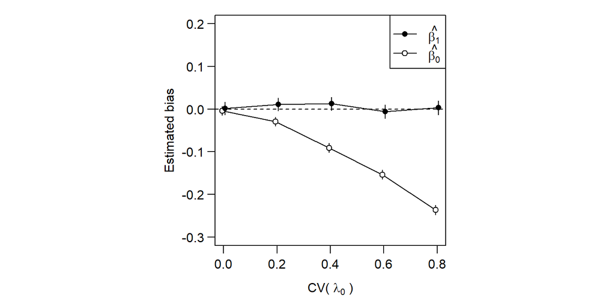

Fig. 2. Bias of beta estimates given individual variation

```r
cvltext <- expression(paste("CV( ", lambda[0], " )"))
x <- seq(0,0.8,0.20)
par(mfrow = c(1,1), mar = c(4,4,1,1), mgp = c(2.4,0.7,0), bty = 'o', pty = 's', las = 0)
offset <- 0.005
plot(0,0, type = 'n', xlim = c(0,0.8), ylim = c(-0.3,0.2),
     xlab = cvltext, ylab = '', las=1)
mtext(side=2, 'Estimated bias', line = 2.5, las=0)
abline(h = 0, lty = 2)
addRB(x-offset, onefit(1), mean = 'D', se = 'seD', type = 'o', pch = 21, bg = 'white')
addRB(x+offset, onefit(1), mean = 'Dgrf', se = 'seDgrf', type = 'o', pch = 16)

legend ('topright', legend = c(expression(italic(hat(beta[1]))),
                               expression(italic(hat(beta[0])))),
        pch=c(16,21), pt.bg = 'white', lty = 1)
```

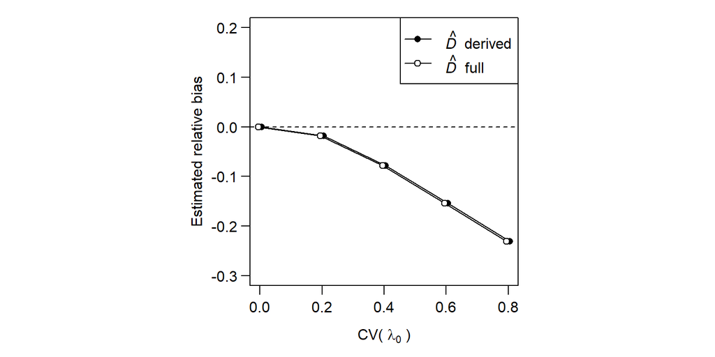

Fig. 3. Bias of density estimates given individual variation

```r
cvltext <- expression(paste("CV( ", lambda[0], " )"))
x <- seq(0,0.8,0.20)
par(mfrow = c(1,1), mar = c(4,4,1,1), mgp = c(2.4,0.7,0), bty = 'o', pty = 's', las = 0)
offset <- 0.005
plot(0,0, type = 'n', xlim = c(0,0.8), ylim = c(-0.3,0.2),
     xlab = cvltext, ylab = '', las=1)
mtext(side=2, 'Estimated relative bias', line = 2.5, las=0)
abline(h = 0, lty = 2)
addRB(x+offset, onefit(1), mean = 'BD', se = 'seBD', type = 'o', pch = 16)
addRB(x-offset, onefit(2), mean = 'BD', se = 'seBD', type = 'o', pch = 21, bg = 'white')

legend ('topright', legend = c(expression(italic(hat(D)) ~~ 'derived'),
                               expression(italic(hat(D)) ~~ 'full')),
                               pch=c(16,21), pt.bg = 'white', lty = 1, y.intersp=1.3)
```

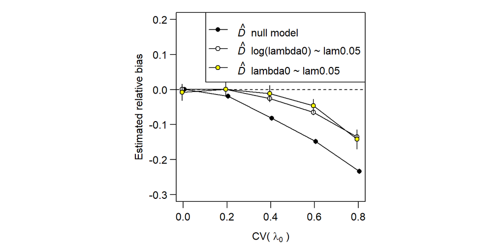

Fig. 4. Bias of density estimates given individual variation, with individual covariate

```r
cvltext <- expression(paste("CV( ", lambda[0], " )"))
x <- seq(0,0.8,0.20)
par(mfrow = c(1,1), mar = c(4,4,1,1), mgp = c(2.4,0.7,0), bty = 'o', pty = 's', las = 0)
offset <- 0.005
plot(0,0, type = 'n', xlim = c(0,0.8), ylim = c(-0.3,0.2),
     xlab = cvltext, ylab = '', las=1)
mtext(side=2, 'Estimated relative bias', line = 2.5, las=0)
abline(h = 0, lty = 2)
addRB(x+offset, onefit(1, MhSsims2), mean = 'BD', se = 'seBD', type = 'o', pch = 16)
addRB(x-offset, onefit(2, MhSsims2), mean = 'BD', se = 'seBD', type = 'o', pch = 21, bg = 'white')
addRB(x-offset, onefit(1, MhSsims3), mean = 'BD', se = 'seBD', type = 'o', pch = 21, bg = 'yellow')

legend ('topright', legend = c(expression(italic(hat(D)) ~~ 'null model'),
                               expression(italic(hat(D)) ~~ 'log(lambda0) ~ lam0.05'),
                               expression(italic(hat(D)) ~~ 'lambda0 ~ lam0.05')),
        pch = c(16,21,21), pt.bg = c('white', 'white', 'yellow'),
        lty = 1, y.intersp=1.3)
```

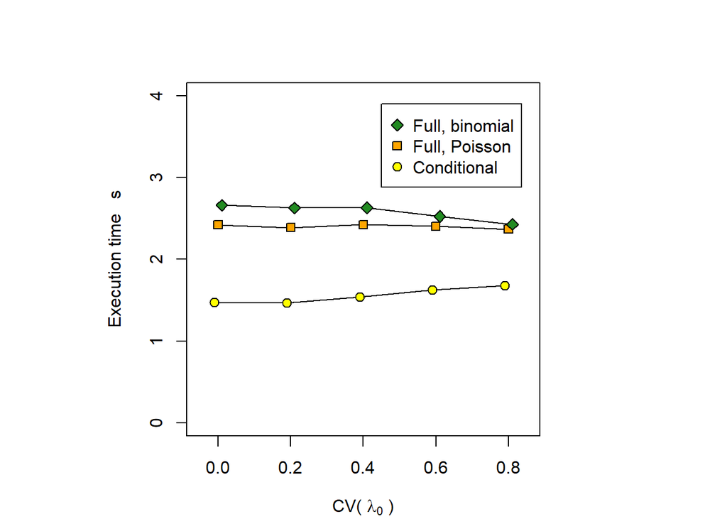

```r
par(mar=c(4,4,4,4), pty='s')
plot(0,0,type='n',xlim=c(-0.05,0.85), ylim=c(0,4),
     xlab = cvltext, ylab = 'Execution time   s' )
offset <- c(-0.01,0,0.01)
cols <- c('yellow', 'orange','forestgreen')
for (f in 1:3) {
    df <- onefit(f)
    x <- df$CVlambda0 + offset[f]
    segments (x, df$time + 2* df$setime, x, df$time - 2* df$setime)
    points (x, df$time, type = 'o', pch = 20+f, bg = cols[f],cex = 1.2)
}
legend(0.45,3.9, legend=c('Full, binomial', 'Full, Poisson', 'Conditional'),
       pch = (21:23)[3:1], pt.cex = 1.2, pt.bg = cols[3:1] )
```

```r
# proportion of time saved
1-onefit(1)$time /  onefit(2)$time
```

```
## [1] 0.3918 0.3861 0.3652 0.3239 0.2904
```

```r
comparefit <- function(fit1 = 1, fit2 = 2) {
  onesim <- function (sim, parm, fn, ratio = FALSE) {
    if (ratio) {
      obs <-sapply(sim, function(x) x[[fit2]][parm,'beta']) /
        sapply(sim, function(x) x[[fit1]][parm,'beta'])
    } else {
      obs <- sapply(sim, function(x) x[[fit1]][parm,'beta']) -
        sapply(sim, function(x) x[[fit2]][parm,'beta'])
    }
    fn(obs)
  }
  df <- data.frame(
    CVlambda0   = seq(0,0.8,0.2),
    nvalid      = sapply(MhSsims$output, onesim, 'D',        fn = nv),
    deltaD      = sapply(MhSsims$output, onesim, 'D',        fn = mn),
    sedeltaD    = sapply(MhSsims$output, onesim, 'D',        fn = se),
    deltaDgrf   = sapply(MhSsims$output, onesim, 'D.grf',    fn = mn),
    sedeltaDgrf = sapply(MhSsims$output, onesim, 'D.grf',    fn = se),
    deltatime   = sapply(MhSsims$output, onesim, 'time',     fn = mn),
    sedeltatime = sapply(MhSsims$output, onesim, 'time',     fn = se),
    ratiotime   = sapply(MhSsims$output, onesim, 'time',     fn = mn, ratio = TRUE),
    seratiotime = sapply(MhSsims$output, onesim, 'time',     fn = se, ratio = TRUE)
  )
  df
}
comparefit(1,2)
```

```
##   CVlambda0 nvalid    deltaD  sedeltaD  deltaDgrf sedeltaDgrf deltatime sedeltatime ratiotime seratiotime
## 1       0.0   2000 2.824e-05 5.947e-07 -3.753e-05   7.433e-07   -0.9491    0.010075     1.692    0.008596
## 2       0.2   2000 2.819e-05 6.009e-07 -3.737e-05   7.420e-07   -0.9227    0.010583     1.677    0.008898
## 3       0.4   2000 3.069e-05 6.141e-07 -4.048e-05   7.457e-07   -0.8855    0.010232     1.616    0.008165
## 4       0.6   2000 3.182e-05 5.542e-07 -4.240e-05   6.841e-07   -0.7788    0.009237     1.501    0.006673
## 5       0.8   2000 3.559e-05 6.070e-07 -4.723e-05   7.295e-07   -0.6884    0.008028     1.420    0.005395
```

```r
comparefit(1,3)
```

```
##   CVlambda0 nvalid   deltaD  sedeltaD deltaDgrf sedeltaDgrf deltatime sedeltatime ratiotime seratiotime
## 1       0.0   2000 0.001545 2.326e-05 0.0001531   4.045e-05   -1.1898    0.011735     1.872    0.010331
## 2       0.2   2000 0.001569 2.353e-05 0.0002135   4.683e-05   -1.1618    0.011487     1.859    0.010319
## 3       0.4   2000 0.001607 2.533e-05 0.0001794   4.718e-05   -1.0920    0.011977     1.769    0.009995
## 4       0.6   2000 0.001648 2.821e-05 0.0002417   5.184e-05   -0.9007    0.010378     1.596    0.008393
## 5       0.8   2000 0.001719 2.982e-05 0.0002299   5.580e-05   -0.7476    0.008792     1.473    0.006895
```

## Interpretation

Estimates of coefficient for density-covariate relationship are insensitive to individual variation in $\lambda_0$.

## References

Hines, J. E. and Nichols, J. D. 2002. Investigations of potential bias in the estimation of $\lambda$ using Pradel’s (1996) model for capture–recapture data. Journal of Applied Statistics 29: 573–587.

Nichols, J. D. and Hines, J. E. 2002. Approaches for the direct estimation of $\lambda$, and demographic contributions to $\lambda$, using capture–recapture data, Journal of Applied Statistics 29: 539–568.